# Simulations to assess juvenile survival modeling

Author

Michelle A. Briggs, Ryan N. Kinzer

Published

July 16, 2026

## Methods

We produced simulated datasets to assess the accuracy and precision of two models used to estimate the survival of juvenile Chinook salmon (*Oncorhynchus tshawytscha*) and steelhead (*O. mykiss*) during downstream migration from natal tributaries to Lower Granite Dam. Simulated mark-recapture datasets included four occasions, representing four opportunities to detect each individual fish. The first occasion represented a marking event, the second occasion represented a detection at an in-stream PIT tag array, the third occasion represented detection at Lower Granite Dam in either the spillway or the juvenile bypass system, and the final occasion represented detection downstream of Lower Granite Dam at hydrosystem facilities or PIT tag arrays in the lower Columbia River.

Datasets were simulated under 36 scenarios representing varying numbers of marked fish, survival probabilities, and detection probabilities. The number of tagged fish was either 2000, 1000, or 500. Simulated survival was constant for the first two intervals and was either 0.75, 0.5, or 0.25. Survival for the final interval, representing the probability of survival downstream of Lower Granite Dam, was 0.50 for all scenarios. Detection probability was 1.0 for the first occasion (representing the marking event) and 0.5 for the final occasion (representing detection downstream of Lower Granite Dam) for all scenarios. Detection probability for the second and third occasions was 0.5 and 0.5; 0.25 and 0.25; 0.05 and 0.5; or 0.05 and 0.25. The probability of removal (i.e., censoring) due to transport or lethal sampling was set to 0.02 for all occasions following the marking event. We simulated datasets for all combinations of the number of marked fish, survival, and detection (Table 1), and we ran 500 iterations of each scenario.

Each simulated dataset was analyzed using two models to estimate survival and detection probabilities. We fit a Cormack-Jolly-Seber (CJS) model (Seber 1965; Jolly 1965) implemented using the *marked* package in R (Laake et al. 2013). Survival *s* was allowed to vary freely by interval and detection probability *p* was allowed to vary freely by occasion. The CJS model estimates *s* for each interval and *p* for each occasion; however, the final estimates of *s* and *p* (representing survival and detection downstream of Lower Granite Dam) are confounded. We also fit a CJS model using an m-array approach, following the method of (Burnham et al. 1987). The m-array CJS model estimates *s* and *p* varying by interval and occasion, respectively, and $\lambda$, which represents the product of *s* and *p* for the final occasion.

To assess accuracy and precision of survival and detection estimates, we compared the estimates to the true (simulated) values. We assessed the accuracy of estimates by calculating percent bias and root mean squared error. We calculated percent bias as:

$\text{Percent bias} = \frac{\hat{y}_i- y_i}{y_i}*100$,

where $y_i$ is the true (simulated) value and $\hat{y}_i$ is the estimated value. Root mean squared error (RMSE) was calculated for each metric and scenario as:

$\text{RMSE} = \sqrt{\frac{1}{n} \sum_{i=1}^{n} (\hat{y}_i- y_i)^2}$,

where n is the number of iterations, $y_i$ is the true (simulated) value, and $\hat{y}_i$ is the estimated value.

To assess precision, we examined the median width of the 95% confidence intervals among different scenarios as well as the 2.5 and 97.5 percentiles of the confidence interval width.

Table 1. Scenarios used to generate simulated datasets. Detection probabilities denote simluated values for the second and third occasions; survival probabilities denote simluated values for the first and second intervals. Detection probabilities for the first and fourth occasions were set to 1.0 and 0.5, respectively, for all scenarios. Survival probability for the final (third) interval was set to 0.5 for all scenarios.

| Scenario | Number of marked fish | Detection probabilities | Survival probabilities |
| --- | --- | --- | --- |
| 1 | 2000 | 0.5, 0.5 | 0.75, 0.75 |
| 2 | 2000 | 0.25, 0.25 | 0.75, 0.75 |
| 3 | 2000 | 0.05, 0.5 | 0.75, 0.75 |
| 4 | 2000 | 0.05, 0.25 | 0.75, 0.75 |
| 5 | 2000 | 0.5, 0.5 | 0.5, 0.5 |
| 6 | 2000 | 0.25, 0.25 | 0.5, 0.5 |
| 7 | 2000 | 0.05, 0.5 | 0.5, 0.5 |
| 8 | 2000 | 0.05, 0.25 | 0.5, 0.5 |
| 9 | 2000 | 0.5, 0.5 | 0.25, 0.25 |
| 10 | 2000 | 0.25, 0.25 | 0.25, 0.25 |
| 11 | 2000 | 0.05, 0.5 | 0.25, 0.25 |
| 12 | 2000 | 0.05, 0.25 | 0.25, 0.25 |
| 13 | 1000 | 0.5, 0.5 | 0.75, 0.75 |
| 14 | 1000 | 0.25, 0.25 | 0.75, 0.75 |
| 15 | 1000 | 0.05, 0.5 | 0.75, 0.75 |
| 16 | 1000 | 0.05, 0.25 | 0.75, 0.75 |
| 17 | 1000 | 0.5, 0.5 | 0.5, 0.5 |
| 18 | 1000 | 0.25, 0.25 | 0.5, 0.5 |
| 19 | 1000 | 0.05, 0.5 | 0.5, 0.5 |
| 20 | 1000 | 0.05, 0.25 | 0.5, 0.5 |
| 21 | 1000 | 0.5, 0.5 | 0.25, 0.25 |
| 22 | 1000 | 0.25, 0.25 | 0.25, 0.25 |
| 23 | 1000 | 0.05, 0.5 | 0.25, 0.25 |
| 24 | 1000 | 0.05, 0.25 | 0.25, 0.25 |
| 25 | 500 | 0.5, 0.5 | 0.75, 0.75 |
| 26 | 500 | 0.25, 0.25 | 0.75, 0.75 |
| 27 | 500 | 0.05, 0.5 | 0.75, 0.75 |
| 28 | 500 | 0.05, 0.25 | 0.75, 0.75 |
| 29 | 500 | 0.5, 0.5 | 0.5, 0.5 |
| 30 | 500 | 0.25, 0.25 | 0.5, 0.5 |
| 31 | 500 | 0.05, 0.5 | 0.5, 0.5 |
| 32 | 500 | 0.05, 0.25 | 0.5, 0.5 |
| 33 | 500 | 0.5, 0.5 | 0.25, 0.25 |
| 34 | 500 | 0.25, 0.25 | 0.25, 0.25 |
| 35 | 500 | 0.05, 0.5 | 0.25, 0.25 |
| 36 | 500 | 0.05, 0.25 | 0.25, 0.25 |

## Results

When simulated detection probability was 0.05 on the second occasion, the accuracy and precision of survival estimates declined. Survival estimates were often biased when 500 or 1000 fish were tagged (Figures 2 - 3), with a portion of simulations resulting in underestimates of survival and another portion of simulations estimating survival near 1.0. Bias in survival estimates caused by very low detection probabilities may be reduced by tagging a larger number of fish (e.g., 2000 individuals; Figure 1). High survival also reduced bias in scenarios with low detection probability. Although a larger sample size may increase accuracy when detection probability is very low, confidence intervals were very broad. The median width of 95% confidence intervals around the point estimates of survival were >0.50 in most scenarios with simulated detection probabilities of 0.05. Such high uncertainty may limit the utility of estimates for informing management decisions.

Table 2. Estimates of survival probability from the CJS m-array model by scenario. Detection probability, the number of tagged fish, and survival probability indicate simulated values used to generate datasets. Mean and median estimates summarize the estimates of survival by scenario. Mean bias, median bias, and RMSE were calculated by comparing estimated survival to the simulated survival value.

[output not shown]

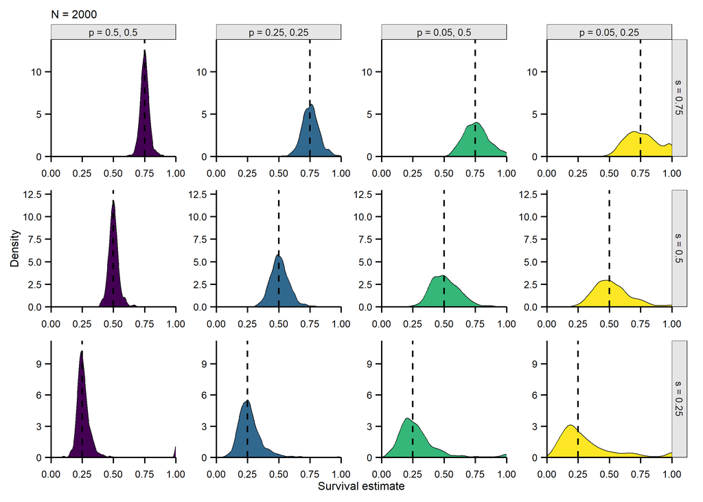

Figure 1: Density plots showing estimates of survival from the m-array CJS model for scenarios with 2000 tagged fish. The vertical dashed lines indicate the true (simulated) survival values. Four levels of detection probability are shown in the column headers, and three levels of survival are indicated by the row labels.

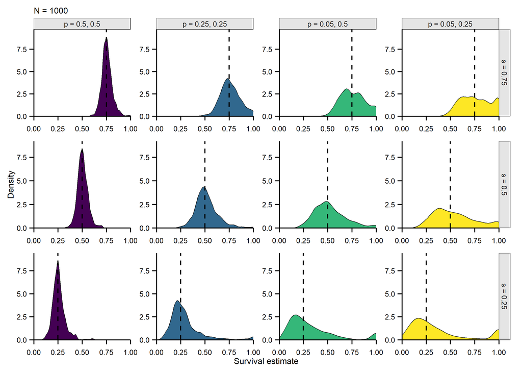

Figure 2: Density plots showing estimates of survival from the m-array CJS model for scenarios with 1000 tagged fish. The vertical dashed lines indicate the true (simulated) survival values. Four levels of detection probability are shown in the column headers, and three levels of survival are indicated by the row labels.

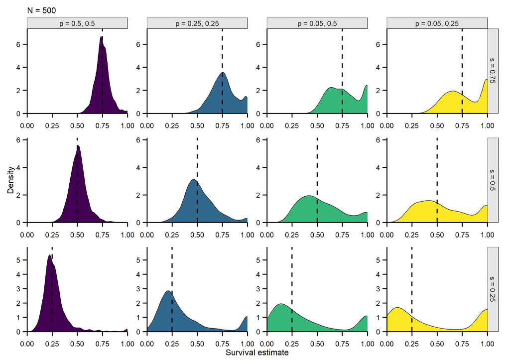

Figure 3: Density plots showing estimates of survival from the m-array CJS model for scenarios with 500 tagged fish. The vertical dashed lines indicate the true (simulated) survival values. Four levels of detection probability are shown in the column headers, and three levels of survival are indicated by the row labels.

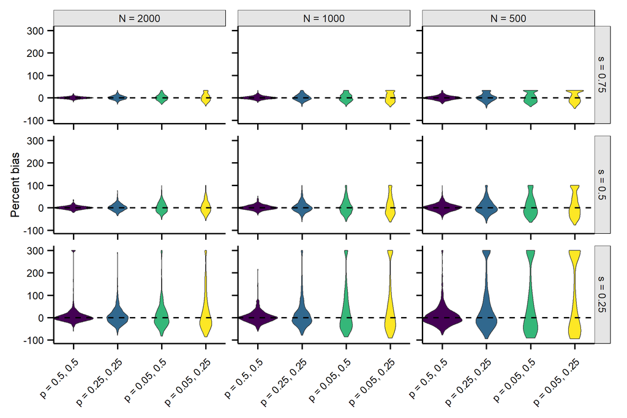

Figure 4: The percent bias of survival estimates from the m-array CJS model by scenario. The simulated number of tagged fish is shown in the column headers, and the simulated survival probability is shown in the row labels. The simulated detection probabilities are indicated on the x-axis. The horizontal dashed line indicates a percent bias of zero, indicating accurate survival estimation.

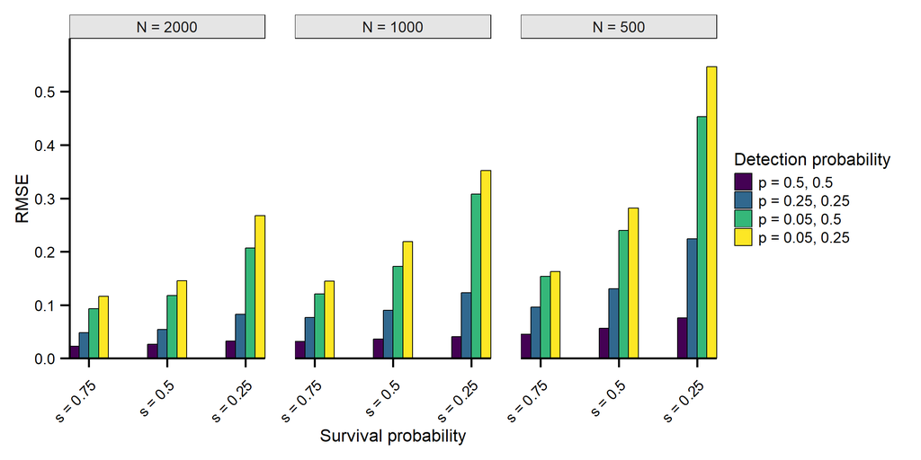

Figure 5: Root mean squared error (RMSE) for survival estimates from the m-array CJS model by scenario.

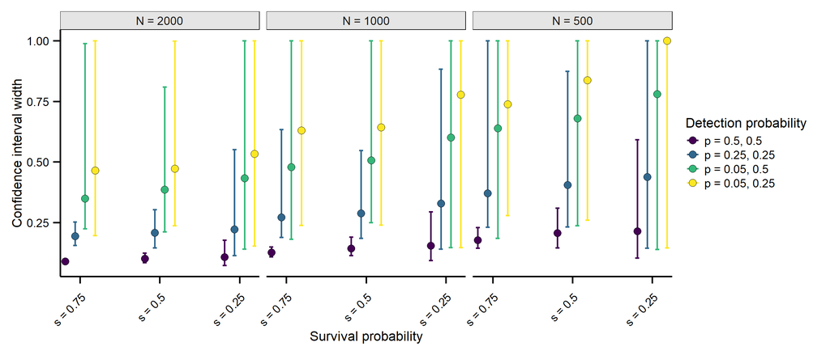

Figure 6: The median width of 95% confidence intervals for survival estimates from the m-array CJS model by scenario. The bars indicate the 2.5 and 97.5 percentiles of the confidence interval widths from each scenario.

## References

Burnham, Kenneth P., David R. Anderson, Gary C. White, Cavell Brownie, and Kenneth H. Pollock. 1987. *Design and Analysis Methods for Fish Survival Experiments Based on Release-Recapture*. American Fisheries Society.

Jolly, G. M. 1965. “Explicit Estimates from Capture-Recapture Data with Both Death and Immigration-Stochastic Model.” *Biometrika* 52. https://doi.org/10.2307/2333826.

Laake, Jeff L., Devin S. Johnson, and Paul B. Conn. 2013. “Marked: An r Package for Maximum Likelihood and Markov Chain Monte Carlo Analysis of Capturerecapture Data.” *Methods in Ecology and Evolution* 4 (9): 885–90. https://doi.org/10.1111/2041-210X.12065.

Seber, G. A. 1965. “A Note on the Multiple-Recapture Census.” *Biometrika* 52. https://doi.org/10.2307/2333827.